# HW-5

Ali Furkan Yavuz

1/12/2019

# Multiple instance learning

In this homework we will use miltiple insatance learning to predict classes of the bags created from the dataset.

## Librarries and Data Preperation

The homewrok requires use of different packages so different libraries recalled and the data from the moodle read.

```r
library(data.table)
library(cluster)
library(factoextra)
library(penalized)
library(pROC)

DT=as.data.table(read.csv(file = '/Users/alifurkanyavuz/Desktop/IE582/HW5/Musk1.csv'))
```

The data needs to be scaled before the callssification so first unncessary colums which includes bag information removed and the data scaled. Euclidean and Manhattan distances are used and stored with different names for further use.

```r
DT_first_two_columns=DT[,1:2]
DT_rest=DT[,3:ncol(DT)]
DT_scaled=as.data.table(scale(DT_rest))

dt_dist_euc=as.data.table(as.matrix(dist(DT_scaled)))

dt_dist_man=as.data.table(as.matrix(dist(DT_scaled,method = "manhattan")))

dist_euc=dist(DT_scaled)
dist_man=dist(DT_scaled,method = "manhattan")
```

## Hierarchical Clustring

First hierarchical clustering applied to data using average method for both euclidean and manhattan cases.

```r
hclust_euc_avg <- hclust(dist_euc, method = 'average')
hclust_man_avg <- hclust(dist_man, method = 'average')
clust_euc_k<-cutree(hclust_euc_avg, k = 3)
clust_man_k<-cutree(hclust_man_avg, k = 3)
```

Then we need to find k values to cut the trees, a function used to find best k values.

As can be seen from the graphs best k value for the manhattan and euclidean is 3 so we will use k=3 in the application of classification algorithms

```r
k_euc=fviz_nbclust(DT_rest,kmeans,method = "silhouette",dist(DT_rest,method = "euclidean"))

k_man=fviz_nbclust(DT_rest,kmeans,method = "silhouette",dist(DT_rest,method = "manhattan"))
```

Optimal Cluster Euclidean

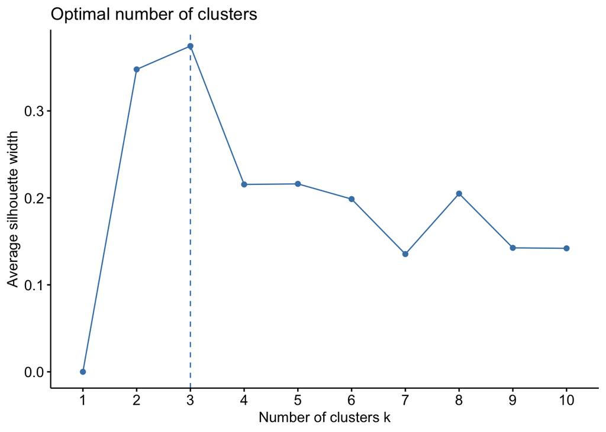

```r
plot(k_euc)
```

Optimal Cluster Manhattan

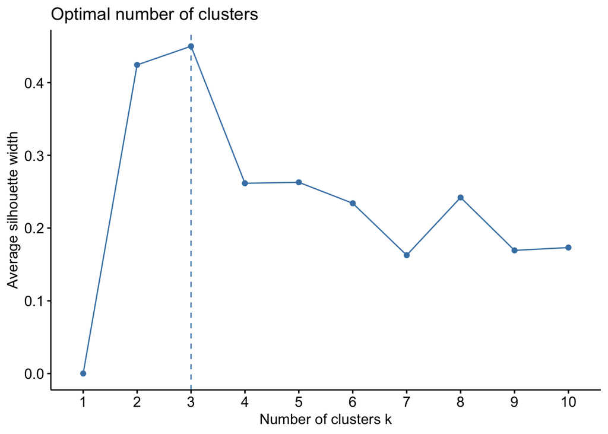

```r
plot(k_man)
```

The trees are cutted based on the k value found above.

```r
clust_euc_k<-cutree(hclust_euc_avg, k = 3)
clust_man_k<-cutree(hclust_man_avg, k = 3)
```

Centers of the euclidean case found using column means. Then, columns renamed to avoid confusion and the result of the calculations is stored.

```r
dt_dist_euc_and_clust=cbind(dt_dist_euc,clust_euc_k)
colnames(dt_dist_euc_and_clust)

hclust_euc_cent_1=as.data.table(colMeans(dt_dist_euc_and_clust[clust_euc_k=="1"]))
hclust_euc_cent_2=as.data.table(colMeans(dt_dist_euc_and_clust[clust_euc_k=="2"]))
hclust_euc_cent_3=as.data.table(colMeans(dt_dist_euc_and_clust[clust_euc_k=="3"]))
hclust_euc_dist_to_cent=cbind(hclust_euc_cent_1,hclust_euc_cent_2,hclust_euc_cent_3)
bags_and_hclust_euc_dist_to_cent=cbind(DT_first_two_columns,hclust_euc_dist_to_cent)
colnames(bags_and_hclust_euc_dist_to_cent)[1]="X1"
colnames(bags_and_hclust_euc_dist_to_cent)[2]="bag_id"
colnames(bags_and_hclust_euc_dist_to_cent)[3]="cent_1"
colnames(bags_and_hclust_euc_dist_to_cent)[4]="cent_2"
colnames(bags_and_hclust_euc_dist_to_cent)[5]="cent_3"
colnames(bags_and_hclust_euc_dist_to_cent)
bags_and_hclust_euc_dist_to_cent=bags_and_hclust_euc_dist_to_cent[-476]

results_hclust_euc=bags_and_hclust_euc_dist_to_cent[,.(mean(X1),mean(cent_1),mean(cent_2),mean(cent_3)),by="bag_id"]
```

Centers of the manhattan case found using column means. Then, columns renamed to avoid confusion and the result of the calculations is stored.

```r
dt_dist_man_and_clust=cbind(dt_dist_man,clust_man_k)
colnames(dt_dist_man_and_clust)

hclust_man_cent_1=as.data.table(colMeans(dt_dist_man_and_clust[clust_man_k=="1"]))
hclust_man_cent_2=as.data.table(colMeans(dt_dist_man_and_clust[clust_man_k=="2"]))
hclust_man_cent_3=as.data.table(colMeans(dt_dist_man_and_clust[clust_man_k=="3"]))
hclust_man_dist_to_cent=cbind(hclust_man_cent_1,hclust_man_cent_2,hclust_man_cent_3)
bags_and_hclust_man_dist_to_cent=cbind(DT_first_two_columns,hclust_man_dist_to_cent)
colnames(bags_and_hclust_man_dist_to_cent)[1]="X1"
colnames(bags_and_hclust_man_dist_to_cent)[2]="bag_id"
colnames(bags_and_hclust_man_dist_to_cent)[3]="cent_1"
colnames(bags_and_hclust_man_dist_to_cent)[4]="cent_2"
colnames(bags_and_hclust_man_dist_to_cent)[5]="cent_3"
colnames(bags_and_hclust_man_dist_to_cent)
bags_and_hclust_man_dist_to_cent=bags_and_hclust_man_dist_to_cent[-476]

results_hclust_man=bags_and_hclust_man_dist_to_cent[,.(mean(X1),mean(cent_1),mean(cent_2),mean(cent_3)),by="bag_id"]
```

## Clustring K-Medoids

Then we need to cluster data useing k medoids technic for both manhattan and euclidean cases.Note: Used k values found earlier.

```r
pam_euc <- pam(dist_euc, 3,metric = "euclidean")

pam_man <- pam(dist_man, 3,metric = "manhattan")
```

Then distances for centers for bith euclidean and manhattan cases are are calculated.

```r
pam_euc_meds
euc_dist_to_cent_1=dt_dist_euc[,107]
euc_dist_to_cent_2=dt_dist_euc[,89]
euc_dist_to_cent_3=dt_dist_euc[,68]
euc_dist_to_cent=cbind(euc_dist_to_cent_1,euc_dist_to_cent_2,euc_dist_to_cent_3)

pam_man_meds
man_dist_to_cent_1=dt_dist_man[,11]
man_dist_to_cent_2=dt_dist_man[,59]
man_dist_to_cent_3=dt_dist_man[,57]
man_dist_to_cent=cbind(man_dist_to_cent_1,man_dist_to_cent_2,man_dist_to_cent_3)
```

Then averages per classes are calculated for both euclidean and manhattan. And also columns are renamed to avoid confusion.

```r
bags_and_euc_dist_to_cent=cbind(DT_first_two_columns,euc_dist_to_cent)
colnames(bags_and_euc_dist_to_cent)[1]="X1"
colnames(bags_and_euc_dist_to_cent)[2]="bag_id"
colnames(bags_and_euc_dist_to_cent)[3]="cent_1"
colnames(bags_and_euc_dist_to_cent)[4]="cent_2"
colnames(bags_and_euc_dist_to_cent)[5]="cent_3"
colnames(bags_and_euc_dist_to_cent)

results_kmeds_euc=bags_and_euc_dist_to_cent[,.(mean(X1),mean(cent_1),mean(cent_2),mean(cent_3)),by="bag_id"]

#bind with bag names man and calculate averages
bags_and_man_dist_to_cent=cbind(DT_first_two_columns,man_dist_to_cent)
colnames(bags_and_man_dist_to_cent)[1]="X1"
colnames(bags_and_man_dist_to_cent)[2]="bag_id"
colnames(bags_and_man_dist_to_cent)[3]="cent_1"
colnames(bags_and_man_dist_to_cent)[4]="cent_2"
colnames(bags_and_man_dist_to_cent)[5]="cent_3"
colnames(bags_and_man_dist_to_cent)

results_kmeds_man=bags_and_man_dist_to_cent[,.(mean(X1),mean(cent_1),mean(cent_2),mean(cent_3)),by="bag_id"]
```

## Logistic Regresssion Fitting for All Cases

First, is fitting logistic regression with lasso to hierarchical clustering. To fit lasso we need to find optimal lambda. It is found using the following function. Before that data processes to use in the function

```r
colnames(results_hclust_euc)[2]='bag_class'

train_class_hclust_euc= as.numeric(unlist((results_hclust_euc[,2])))
penalized_hclust_euc=results_hclust_euc[,3:5]

lr_hclust_euc=optL1(response=train_class_hclust_euc, penalized= penalized_hclust_euc,fusedl=TRUE,model="logistic", fold=10,standardize=TRUE)
```

Best Lambda is the following for this case.

```r
lr_hclust_euc$lambda
```

```
## [1] 1.411014
```

Then the model is fittid to the data and predictions are made but note that there is no test data in this case.

```r
fit_lr_hclust_euc=penalized(response = train_class_hclust_euc, penalized = penalized_hclust_euc, lambda1= lr_hclust_euc$lambda
, fusedl = TRUE, model = "logistic",standardize=TRUE)
fit_lr_hclust_euc
penalized_hclust_euc_frame=as.data.frame(penalized_hclust_euc)
predict_hclust_euc=predict(fit_lr_hclust_euc,penalized=penalized_hclust_euc, data=penalized_hclust_euc_frame)
predict_hclust_euc
predict_hclust_euc[predict_hclust_euc>=0.5]=1
predict_hclust_euc[predict_hclust_euc<0.5]=0
predict_hclust_euc=as.numeric(predict_hclust_euc)
train_class_hclust_euc=as.numeric(train_class_hclust_euc)
```

Then area under the ROC is found to compare preformances later.

```r
auc(train_class_hclust_euc,predict_hclust_euc)
```

```
## Area under the curve: 0.726
```

The same method above applied to hierarchical clustering manhattan case.

```r
colnames(results_hclust_man)[2]='bag_class'
colnames( results_hclust_man)
train_class_hclust_man= as.numeric(unlist((results_hclust_man[,2])))
penalized_hclust_man=results_hclust_man[,3:5]

lr_hclust_man=optL1(response=train_class_hclust_man, penalized= penalized_hclust_man,fusedl=TRUE,model="logistic", fold=10,standardize=TRUE)

lr_hclust_man$lambda

fit_lr_hclust_man=penalized(response = train_class_hclust_man, penalized = penalized_hclust_man, lambda1= lr_hclust_man$lambda
                            , fusedl = TRUE, model = "logistic",standardize=TRUE)
fit_lr_hclust_man
penalized_hclust_man_frame=as.data.frame(penalized_hclust_euc)
predict_hclust_man=predict(fit_lr_hclust_man,penalized=penalized_hclust_man, data=penalized_hclust_man_frame)
predict_hclust_man
predict_hclust_man[predict_hclust_man>=0.5]=1
predict_hclust_man[predict_hclust_man<0.5]=0
predict_hclust_man=as.numeric(predict_hclust_man)
train_class_hclust_man=as.numeric(train_class_hclust_man)
```

Then area under the ROC is found to compare preformances later.

```r
auc(train_class_hclust_man,predict_hclust_man)
```

```
## Area under the curve: 0.683
```

```r
colnames(results_kmeds_euc)[2]='bag_class'
colnames( results_kmeds_euc)
train_class_kmeds_euc= as.numeric(unlist((results_kmeds_euc[,2])))
penalized_kmeds_euc=results_kmeds_euc[,3:5]

lr_kmeds_euc=optL1(response=train_class_kmeds_euc, penalized= penalized_kmeds_euc,fusedl=TRUE,model="logistic", fold=10,standardize=TRUE)

lr_kmeds_euc$lambda

fit_lr_kmeds_euc=penalized(response = train_class_kmeds_euc, penalized = penalized_kmeds_euc, lambda1= lr_kmeds_euc$lambda

                            , fusedl = TRUE, model = "logistic",standardize=TRUE)

penalized_kmeds_euc_frame=as.data.frame(penalized_kmeds_euc)
predict_kmeds_euc=predict(fit_lr_kmeds_euc,penalized=penalized_kmeds_euc, data=penalized_kmeds_euc_frame)
predict_kmeds_euc
predict_kmeds_euc[predict_kmeds_euc>=0.5]=1
predict_kmeds_euc[predict_kmeds_euc<0.5]=0
predict_hkmeds_euc=as.numeric(predict_kmeds_euc)
train_class_kmeds_euc=as.numeric(train_class_kmeds_euc)
```

Then area under the ROC is found to compare preformances later.

```r
auc(train_class_kmeds_euc,predict_kmeds_euc)
```

```
## Area under the curve: 0.6719
```

```r
colnames(results_kmeds_man)[2]='bag_class'
colnames( results_kmeds_man)
train_class_kmeds_man= as.numeric(unlist((results_kmeds_man[,2])))
penalized_kmeds_man=results_kmeds_man[,3:5]

lr_kmeds_man=optL1(response=train_class_kmeds_man, penalized= penalized_kmeds_man,fusedl=TRUE,model="logistic", fold=10,standardize=TRUE)

lr_kmeds_man$lambda

fit_lr_kmeds_man=penalized(response = train_class_kmeds_man, penalized = penalized_kmeds_man, lambda1= lr_kmeds_man$lambda

                           , fusedl = TRUE, model = "logistic",standardize=TRUE)

penalized_kmeds_man_frame=as.data.frame(penalized_kmeds_man)
predict_kmeds_man=predict(fit_lr_kmeds_man,penalized=penalized_kmeds_man, data=penalized_kmeds_man_frame)
predict_kmeds_man
predict_kmeds_man[predict_kmeds_man>=0.5]=1
predict_kmeds_man[predict_kmeds_man<0.5]=0
predict_hkmeds_man=as.numeric(predict_kmeds_man)
train_class_kmeds_man=as.numeric(train_class_kmeds_man)
auc(train_class_kmeds_man,predict_kmeds_man)
```

Then area under the ROC is found to compare preformances later.

```r
auc(train_class_kmeds_man,predict_kmeds_man)
```

```
## Area under the curve: 0.782
```

## Conclusion

The results of the AUC as follows and if the AUC is bigger it means the prediction is better. The best AUC value is found for the K-Medoids Manhattan Case.

```r
auc(train_class_kmeds_man,predict_kmeds_man)
```

```
## Area under the curve: 0.782
```

```r
auc(train_class_kmeds_euc,predict_kmeds_euc)
```

```
## Area under the curve: 0.6719
```

```r
auc(train_class_hclust_man,predict_hclust_man)
```

```
## Area under the curve: 0.683
```

```r
auc(train_class_hclust_euc,predict_hclust_euc)
```

```
## Area under the curve: 0.726
```